# Programming for Data Analysis and Statistics with R

Course Notes

Diren Senger

# Installation Notes

If you haven’t installed R and RStudio yet, use following instructions for the installation:

1. Install R:
- On Windows: https://www.dummies.com/programming/r/how-to-install-r/
- For Linux and Mac: https://cran.r-project.org/doc/FAQ/R-FAQ.html#How-can-R-be-installed_003f
2. Install the free RStudio Desktop Version: https://www.rstudio.com/products/rstudio/#Desktop

Do you know how you can install new R packages? You can read about it here: https://www.dummies.com/programming/r/how-to-install-load-and-unload-packages-in-r/

# RStudio Programming Environment

## Creating a new project

In many statistics classes they teach you, that you should set a working directory:

```r
setwd("~/Documents/")
```

It can be helpful to create a project instead. All files within the project’s directory will automatically have the correct working directory. In this way you can create new files and start coding easily.

1. Click File -> New Project… Even when you choose “Existing Directory” you will still be able to create a new directory

[figure not shown]

2. Enter the diretory path straight away, or click on browse.

[figure not shown]

3. Choose an existing directory or create a new one

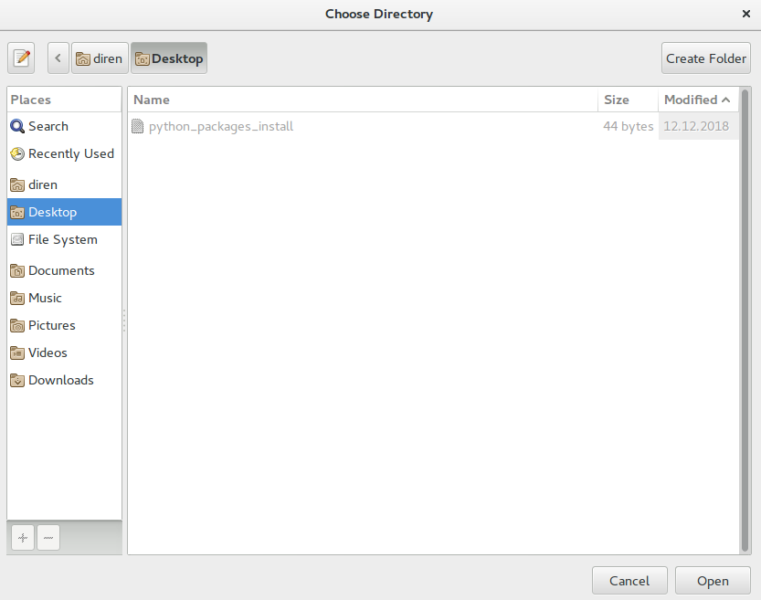

## RStudio screen

[figure not shown]

### Questions

1. If you type code directly in the console, will the objects you create occur in the environment frame?  
Yes. All code you run will result in objects saved in the environment. You can click on the small broom symbol to delete all objects.  
2. When I want to close R, there is this pop-up window asking ‘Save workspace image to ~/Documents/informatica/R/.RData?’. What does this mean?  
When you save the workspace, all object you created within the environment will be retained.

## R Workflow

# Preparing your data for analysis

## Reading the data

Usually, you would use the “csv” format to read data into R. Optimally, you have exactly one line for the header. Make sure to choose the correct separator. You also have to tell R whether your file has a header or not.

```r
df <- read.table("beedata.csv")
```

```
## Error in scan(file = file, what = what, sep = sep, quote = quote, dec = dec, : line 2 did not have 2 elements
```

That did not work. Oh, yes, the separator!

```r
df <- read.table("beedata.csv", sep = ",")
```

| V1 | V2 | V3 | V4 | V5 | V6 | V7 | V8 | V9 | V10 |
| --- | --- | --- | --- | --- | --- | --- | --- | --- | --- |
| time | hive | h | t_i_1 | t_i_2 | t_i_3 | t_i_4 | t_i_5 | t_o | weight_kg |
| 1.565081418e+18 | 4 | NA | 27.25 | 26.375 | 23.4375 | 23.5 | 23.25 | 21.625 | NA |
| 1.565081428e+18 | 4 | NA | 27.25 | 26.4375 | 23.5 | 23.5 | 23.25 | 21.625 | NA |
| 1.565081431e+18 | 13 | 59.0554 | 22.875 | 22.1875 | 23 | 21.8125 | 22.6875 | 22.875 | 10.779 |
| 1.565081438e+18 | 4 | NA | 27.25 | 26.375 | 23.5 | 23.5625 | 23.25 | 21.625 | NA |

Looks ok, but we forgot the heading:

```r
df <- read.table("beedata.csv", sep = ",", header = T)
```

| time | hive | h | t_i_1 | t_i_2 | t_i_3 | t_i_4 | t_i_5 | t_o | weight_kg |
| --- | --- | --- | --- | --- | --- | --- | --- | --- | --- |
| 1.565081e+18 | 4 | NA | 27.250 | 26.3750 | 23.4375 | 23.5000 | 23.2500 | 21.625 | NA |
| 1.565081e+18 | 4 | NA | 27.250 | 26.4375 | 23.5000 | 23.5000 | 23.2500 | 21.625 | NA |
| 1.565081e+18 | 13 | 59.0554 | 22.875 | 22.1875 | 23.0000 | 21.8125 | 22.6875 | 22.875 | 10.779 |
| 1.565081e+18 | 4 | NA | 27.250 | 26.3750 | 23.5000 | 23.5625 | 23.2500 | 21.625 | NA |
| 1.565081e+18 | 4 | NA | 27.250 | 26.3750 | 23.5000 | 23.5625 | 23.2500 | 21.625 | NA |

That looks good!

Alternatively, we can use “read.csv”. In this case, the default parameters work for us.

```r
df <- read.csv("beedata.csv")
```

## Transforming data

E.g. converting kg to g:

```r
df$weight_g <- df$weight_kg*1000
```

Dealing with the timestamp

```r
df$time <- as.POSIXct(df$time/1000000000, origin="1970-01-01")
```

| time | hive | h | t_i_1 | t_i_2 | t_i_3 | t_i_4 | t_i_5 | t_o | weight_kg | weight_g |
| --- | --- | --- | --- | --- | --- | --- | --- | --- | --- | --- |
| 2019-08-06 10:50:18 | 4 | NA | 27.250 | 26.3750 | 23.4375 | 23.5000 | 23.2500 | 21.625 | NA | NA |
| 2019-08-06 10:50:28 | 4 | NA | 27.250 | 26.4375 | 23.5000 | 23.5000 | 23.2500 | 21.625 | NA | NA |
| 2019-08-06 10:50:31 | 13 | 59.0554 | 22.875 | 22.1875 | 23.0000 | 21.8125 | 22.6875 | 22.875 | 10.779 | 10779 |
| 2019-08-06 10:50:38 | 4 | NA | 27.250 | 26.3750 | 23.5000 | 23.5625 | 23.2500 | 21.625 | NA | NA |
| 2019-08-06 10:50:48 | 4 | NA | 27.250 | 26.3750 | 23.5000 | 23.5625 | 23.2500 | 21.625 | NA | NA |

## Subsetting data

You can use squared brackets and boolean expressions to choose lines and columns: df[<expression to choose lines>,<expression to choose columns>]

Select and plot data from hive 4:

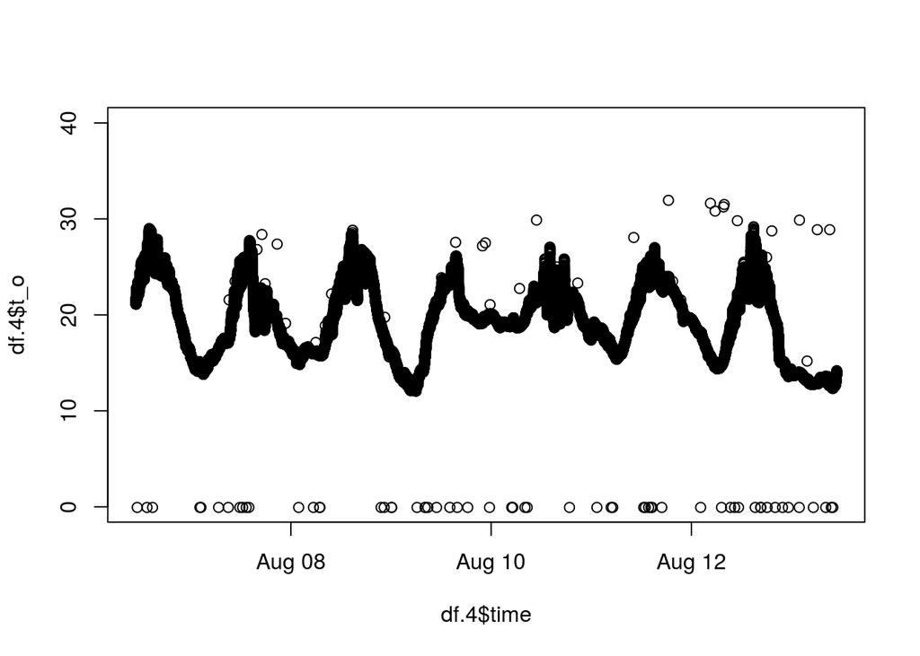

```r
df.4 <- df[df$hive==4,]
plot(df.4$time, df.4$t_o, ylim=c(0,40))
```

Select only the first 1000 lines:

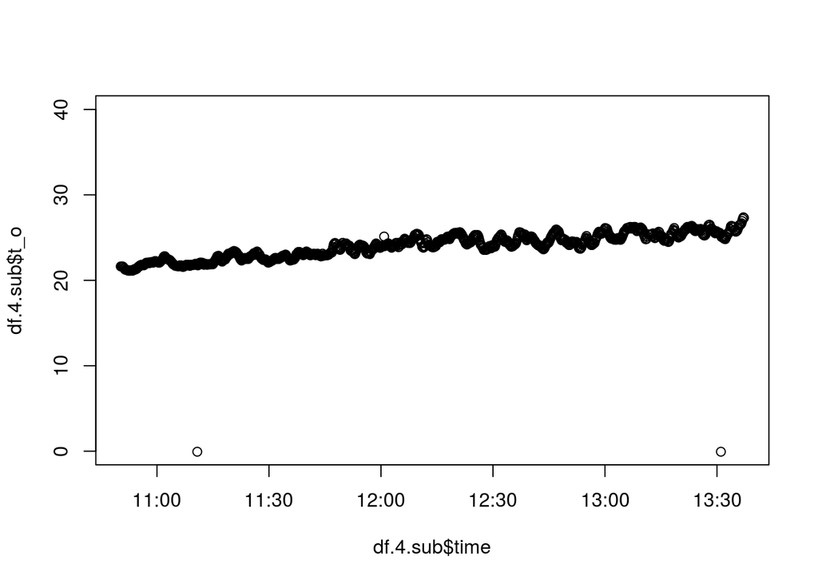

```r
df.4.sub <- df.4[1:1000,]
plot(df.4.sub$time, df.4.sub$t_o, ylim=c(0,40))
```

Delete columns/ Choose only some columns:

```r
names(df)
```

```
##  [1] "time"      "hive"      "h"         "t_i_1"     "t_i_2"
##  [6] "t_i_3"     "t_i_4"     "t_i_5"     "t_o"       "weight_kg"
## [11] "weight_g"
```

```r
df.some <- df[, c(1,2,10)]
```

| time | hive | weight_kg |
| --- | --- | --- |
| 2019-08-06 10:50:18 | 4 | NA |
| 2019-08-06 10:50:28 | 4 | NA |
| 2019-08-06 10:50:31 | 13 | 10.779 |
| 2019-08-06 10:50:38 | 4 | NA |
| 2019-08-06 10:50:48 | 4 | NA |

You can also use:

```r
df.same <- df[, c("time", "hive", "weight_kg")]
```

[output not shown]

```r
df.or <- df[, -c(3:9,11)]
```

| time | hive | weight_kg |
| --- | --- | --- |
| 2019-08-06 10:50:18 | 4 | NA |
| 2019-08-06 10:50:28 | 4 | NA |
| 2019-08-06 10:50:31 | 13 | 10.779 |
| 2019-08-06 10:50:38 | 4 | NA |
| 2019-08-06 10:50:48 | 4 | NA |

## Useful functions

- summary
- head
- tail
- sum
- mean

## Exercises

1. Read the data “allForarexData.csv”

```r
flight <- read.table("allForarexData.csv", header = T, sep = ",")
```

2. Convert Exp0_OxygenTemp and Exp1_OxygenTemp. Devide by 1000

```r
flight$Exp0_OxygenTemp <- flight$Exp0_OxygenTemp/1000
flight$Exp1_OxygenTemp <- flight$Exp1_OxygenTemp/1000
```

3. What are the means of Exp0_OxygenTemp and Exp1_OxygenTemp?

```r
mean(flight$Exp0_OxygenTemp)
```

```
## [1] 21.9658
```

```r
mean(flight$Exp1_OxygenTemp)
```

```
## [1] 18.33506
```

4. Process the timestamp. The time was measured in seconds.

```r
flight$timeStamp <- as.POSIXct(flight$timeStamp, origin="1970-01-01")
```

5. When was the first measurement? When was the last measurement?

```r
min(flight$timeStamp)
```

```
## [1] "2019-03-08 18:59:18 CET"
```

```r
max(flight$timeStamp)
```

```
## [1] "2019-03-09 10:34:47 CET"
```

6. Create a subset containing only data measured after 2019-03-09 10:25:52.

```r
flight.subtime <- flight[flight$timeStamp>as.POSIXct("2019-03-09 10:25:52"),]
```

7. Difficult: Exclude columns, where all measurements are the same.

## Excluding missing values

```r
df.no.na.weight <-  df[!is.na(df$weight_kg),]
df.no.na <- df[complete.cases(df),]
```

# R Data types

## Character

```r
firstname <- "Diren"
surname <- "Senger"
name <- paste(firstname, surname)
name
```

```
## [1] "Diren Senger"
```

## Numeric

```r
a <- 1.5
b <- 2
c <- a + b
c
```

```
## [1] 3.5
```

```r
d <- b*c/a
d
```

```
## [1] 4.666667
```

```r
e <- d^2
e
```

```
## [1] 21.77778
```

```r
f <- as.integer(3.14)
f
```

```
## [1] 3
```

```r
as.numeric("5")
```

```
## [1] 5
```

## Logical

```r
a <- TRUE
b <- FALSE

# or
a|b
```

```
## [1] TRUE
```

```r
# and
a&b
```

```
## [1] FALSE
```

```r
# not
!a
```

```
## [1] FALSE
```

```r
4 == 5
```

```
## [1] FALSE
```

```r
4 < 5
```

```
## [1] TRUE
```

```r
4>=4
```

```
## [1] TRUE
```

```r
# functions can return locicals
is.na(3)
```

```
## [1] FALSE
```

## Vectors

```r
# a simple numeric vector
myvector <- c(1,4,6)
myvector
```

```
## [1] 1 4 6
```

```r
# a vector of type character
myfamily <- c("Paula", "Ali", "Emma")
myfamily
```

```
## [1] "Paula" "Ali"   "Emma"
```

```r
# get the first element of a vector
myfamily[1]
```

```
## [1] "Paula"
```

```r
# apply function to all items:
myvector + 1
```

```
## [1] 2 5 7
```

```r
paste(myfamily, "Meier")
```

```
## [1] "Paula Meier" "Ali Meier"   "Emma Meier"
```

```r
# concatenate vectors:
longervector <- c(myvector, 5:7)
longervector
```

```
## [1] 1 4 6 5 6 7
```

```r
# create a sequence
odd <- seq(from = 1, to = 10, by = 2)
odd
```

```
## [1] 1 3 5 7 9
```

```r
# create a boring sequence
boring <- rep(1, 10)
boring
```

```
##  [1] 1 1 1 1 1 1 1 1 1 1
```

## Data frames

```r
# Creating a data frame
family.frame <- data.frame(index = 1:3, firstname = myfamily, surname = rep("Meier", 3))
```

| index | firstname | surname |
| --- | --- | --- |
| 1 | Paula | Meier |
| 2 | Ali | Meier |
| 3 | Emma | Meier |

## Exercises

1. Create following sequences:
- 4, 8, 12, 16, 20, 24, 28
- 10, 8, 6, 4, 2, 0
- repeat “chocolate” 10 times in a vector

```r
seq(4,28,4)
```

```
## [1]  4  8 12 16 20 24 28
```

```r
seq(10,0,-2)
```

```
## [1] 10  8  6  4  2  0
```

```r
rep("chocolate", 10)
```

```
##  [1] "chocolate" "chocolate" "chocolate" "chocolate" "chocolate"
##  [6] "chocolate" "chocolate" "chocolate" "chocolate" "chocolate"
```

2. Starting with the following code, calculate a / b. You might have to google for a function to deal with the string.

```r
a <- "5555555"
b <- 3
```

```r
as.numeric(a) / b
```

```
## [1] 1851852
```

3. Select the lines of the bee data set where the hive number is 13 or 14.

```r
df.13or14 <- df[df$hive==13|df$hive==14,]
```

4. Starting with following code, create the filename “group3trial1.csv”

```r
group <- 3
trial <- 1
```

```r
paste("group", group, "trial", trial, ".csv", sep="")
```

```
## [1] "group3trial1.csv"
```

5. What are the classes of the beedata’s columns “hive” and “t_i_1”?

```r
class(df$hive)
```

```
## [1] "integer"
```

```r
class(df$t_i_1)
```

```
## [1] "numeric"
```

6. Difficult: How can you print the classes of all columns?

```r
sapply(df, class)
```

```
## $time
## [1] "POSIXct" "POSIXt"
##
## $hive
## [1] "integer"
##
## $h
## [1] "numeric"
##
## $t_i_1
## [1] "numeric"
##
## $t_i_2
## [1] "numeric"
##
## $t_i_3
## [1] "numeric"
##
## $t_i_4
## [1] "numeric"
##
## $t_i_5
## [1] "numeric"
##
## $t_o
## [1] "numeric"
##
## $weight_kg
## [1] "numeric"
##
## $weight_g
## [1] "numeric"
```

```r
str(df)
```

```
## 'data.frame':    171299 obs. of  11 variables:
##  $ time     : POSIXct, format: "2019-08-06 10:50:18" "2019-08-06 10:50:28" ...
##  $ hive     : int  4 4 13 4 4 4 4 4 4 4 ...
##  $ h        : num  NA NA 59.1 NA NA ...
##  $ t_i_1    : num  27.2 27.2 22.9 27.2 27.2 ...
##  $ t_i_2    : num  26.4 26.4 22.2 26.4 26.4 ...
##  $ t_i_3    : num  23.4 23.5 23 23.5 23.5 ...
##  $ t_i_4    : num  23.5 23.5 21.8 23.6 23.6 ...
##  $ t_i_5    : num  23.2 23.2 22.7 23.2 23.2 ...
##  $ t_o      : num  21.6 21.6 22.9 21.6 21.6 ...
##  $ weight_kg: num  NA NA 10.8 NA NA ...
##  $ weight_g : num  NA NA 10779 NA NA ...
```

```r
lapply(df, class)
```

```
## $time
## [1] "POSIXct" "POSIXt"
##
## $hive
## [1] "integer"
##
## $h
## [1] "numeric"
##
## $t_i_1
## [1] "numeric"
##
## $t_i_2
## [1] "numeric"
##
## $t_i_3
## [1] "numeric"
##
## $t_i_4
## [1] "numeric"
##
## $t_i_5
## [1] "numeric"
##
## $t_o
## [1] "numeric"
##
## $weight_kg
## [1] "numeric"
##
## $weight_g
## [1] "numeric"
```

# Conditions - If and Else

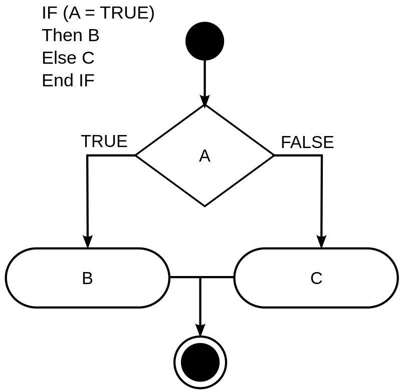

If-Else

```r
goodWeather <- FALSE
if(goodWeather){
  print("Let's go to the beach!")
} else{
  print("Let's eat pizza.")
}
```

```
## [1] "Let's eat pizza."
```

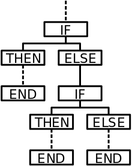

If-Else-If

```r
myfamily
```

```
## [1] "Paula" "Ali"   "Emma"
```

```r
if("Paula" %in% myfamily){
  print("Paula is family.")
} else if ("Ali" %in% myfamily){
  print("Ali is family.")
} else {
  print("Who is family now?")
}
```

```
## [1] "Paula is family."
```

## Exercises

Imagine somebody tells you the age of two of her friends, Ali and Bea. If Ali is older than Bea print “Ali is older than Bea.”. If Bea is older than Ali, print “Bea is older than Ali.”.

```r
Ali <- 5555/111
Bea <- 10*5
```

```r
if(Ali>Bea){
  print("Ali is older than Bea.")
} else{
  print("Bea is older than Ali.")
}
```

```
## [1] "Ali is older than Bea."
```

The price of a small bar of chocolate is 1 Euro. For a medium bar of chocolate you have to pay 3 Euros and for a large bar you have to pay 5 Euros. Somebody tells you how much money she has. Tell her, how much chocolate she can buy (Eg. print “You can buy a small bar of chocolate.”)

```r
money <- -4
```

First version:

```r
if(money < 1){
  print("no chocolate")
}else if(money < 3){
  print("small bar")
} else if(money < 5){
  print("medium bar")
} else if(money>=5){
  print("large bar")
}
```

```
## [1] "no chocolate"
```

Second version:

```r
if(money >= 5){
  print("You can buy a large bar of chocolate.")
} else if (money >= 3){
  print("You can buy a medium bar of chocolate.")
} else if (money >= 1){
  print("You can buy a small bar of chocolate.")
} else{
  print("Sorry, you can't buy any chocolate.")
}
```

```
## [1] "Sorry, you can't buy any chocolate."
```

# For and While

## For

```r
for(j in 1:10){
  print(j)
}
```

```
## [1] 1
## [1] 2
## [1] 3
## [1] 4
## [1] 5
## [1] 6
## [1] 7
## [1] 8
## [1] 9
## [1] 10
```

```r
for(i in 1:length(myfamily)){
  print(paste(myfamily[i], "is family."))
}
```

```
## [1] "Paula is family."
## [1] "Ali is family."
## [1] "Emma is family."
```

Often you will find a loop written with apply/ lapply or sapply. You will always be able to use the for-syntax instead. Apply can be used for arrays. You have to specify whether you want to loop over rows (1) or columns (2). Lapply can be used for lists. Sapply does the same as lapply, but simplifies the output, e.g. returning a vector instead of a named list.

```r
for(i in 1:ncol(df)){
  name <- names(df)[i]
  colclass <- class(df[,i])
  print(paste(name, ":", colclass))
}
```

```
## [1] "time : POSIXct" "time : POSIXt"
## [1] "hive : integer"
## [1] "h : numeric"
## [1] "t_i_1 : numeric"
## [1] "t_i_2 : numeric"
## [1] "t_i_3 : numeric"
## [1] "t_i_4 : numeric"
## [1] "t_i_5 : numeric"
## [1] "t_o : numeric"
## [1] "weight_kg : numeric"
## [1] "weight_g : numeric"
```

```r
apply(df, 2, class)
```

```
##        time        hive           h       t_i_1       t_i_2       t_i_3
## "character" "character" "character" "character" "character" "character"
##       t_i_4       t_i_5         t_o   weight_kg    weight_g
## "character" "character" "character" "character" "character"
```

```r
lapply(df, class)
```

```
## $time
## [1] "POSIXct" "POSIXt"
##
## $hive
## [1] "integer"
##
## $h
## [1] "numeric"
##
## $t_i_1
## [1] "numeric"
##
## $t_i_2
## [1] "numeric"
##
## $t_i_3
## [1] "numeric"
##
## $t_i_4
## [1] "numeric"
##
## $t_i_5
## [1] "numeric"
##
## $t_o
## [1] "numeric"
##
## $weight_kg
## [1] "numeric"
##
## $weight_g
## [1] "numeric"
```

```r
sapply(df, class)
```

```
## $time
## [1] "POSIXct" "POSIXt"
##
## $hive
## [1] "integer"
##
## $h
## [1] "numeric"
##
## $t_i_1
## [1] "numeric"
##
## $t_i_2
## [1] "numeric"
##
## $t_i_3
## [1] "numeric"
##
## $t_i_4
## [1] "numeric"
##
## $t_i_5
## [1] "numeric"
##
## $t_o
## [1] "numeric"
##
## $weight_kg
## [1] "numeric"
##
## $weight_g
## [1] "numeric"
```

## While

```r
a <- 2
while(a<1000){
  a <- a^2
  print(a)
}
```

```
## [1] 4
## [1] 16
## [1] 256
## [1] 65536
```

Caution! Make sure you can escape.

```r
while(TRUE){
  print("hahaha")
}
```

## Questions

1. Loop from 1 to 15 and print the square-root of each number

```r
for(i in 1:15){
  print(sqrt(i))
}
```

```
## [1] 1
## [1] 1.414214
## [1] 1.732051
## [1] 2
## [1] 2.236068
## [1] 2.44949
## [1] 2.645751
## [1] 2.828427
## [1] 3
## [1] 3.162278
## [1] 3.316625
## [1] 3.464102
## [1] 3.605551
## [1] 3.741657
## [1] 3.872983
```

```r
for(i in 1:15){
  print(sqrt(i))
}
```

```
## [1] 1
## [1] 1.414214
## [1] 1.732051
## [1] 2
## [1] 2.236068
## [1] 2.44949
## [1] 2.645751
## [1] 2.828427
## [1] 3
## [1] 3.162278
## [1] 3.316625
## [1] 3.464102
## [1] 3.605551
## [1] 3.741657
## [1] 3.872983
```

2. The function “rbinom(1,1,0.9)” models a very unfair coin, which shows the head (1) with a probability of 90 %. Flip this coin until you get tail (0). Count how many times you flipped the coin.

```r
coin <- rbinom(1,1,0.9)
counter <- 0
while(coin==1){
  coin <- rbinom(1,1,0.9)
  counter <- counter +1
}
 print(counter)
```

```
## [1] 3
```

Other solution

```r
coin <- 1
index <- 0
while(coin!=0){
  coin <- rbinom(1,1,0.9)
  index <- index +1
}
index
```

```
## [1] 2
```

3. Repeat each character of the string “Summer” 3 times. Combine all characters to a new string.

```r
s <- "summer"
s1 <- ""
for(i in 1:nchar(s)){
  for(j in 1:3){
    s1 <- paste(s1, substr(s, i, i), sep = "")
  }
}
s1
```

```
## [1] "sssuuummmmmmeeerrr"
```

4. Difficult: Read in all files in the directory “forarexData” and combine them to a single data frame.

Marielas approach, quite nice that it is avoiding the if-else within the loop. Caution, it is not reading all the files!

```r
dir <- "forarexData"
FileList <- list.files(dir)

data1<-read.csv(paste(dir, FileList[2], sep=""), header = TRUE)
datacombined<-matrix(ncol=ncol(data1))
colnames(datacombined)<-colnames(data1)
tempmatrix<-matrix(ncol=ncol(data1))
colnames(tempmatrix)<-colnames(data1)

for (i in 2:length(FileList)){
  tempmatrix<-read.csv(paste(dir, FileList[i], sep=""))
  datacombined<-rbind(datacombined,tempmatrix)
}
```

Solution with try

```r
dir <- "forarexData/"
files <- list.files(path = dir)
print(files)
for(i in 1:length(files)){
  # use try-catch blog to find out, whether the formating of the file is ok
  try({
    if(!exists("foradata")){
      # if this is the first file to be read, we just read the file
      foradata <- read.table(paste(dir, files[i], sep=""), header = T, sep = ",")
    }else{
      # if we read data before, we combine it with the current file
      foradata <- rbind(foradata, read.table(paste(dir, files[i], sep=""), header = T, sep = ","))
    }
  })

}
# save the table
write.table(foradata, file = "allForaresData2.csv", sep = ",", row.names = F)
```

Solution with try-catch

```r
  dir <- "forarexData/"
  files <- list.files(path = dir)
  print(files)
  for(i in 1:length(files)){
    # use try-catch blog to find out, whether the formating of the file is ok
    tryCatch({
              if(!exists("foradata")){
                # if this is the first file to be read, we just read the file
                foradata <- read.table(paste(dir, files[i], sep=""), header = T, sep = ",")
              }else{
                # if we read data before, we combine it with the current file
                foradata <- rbind(foradata, read.table(paste(dir, files[i], sep=""), header = T, sep = ","))
              }
        },
        # handling of warnings, if there was some weird formating
    warning = function(warning_condition){
      print(paste("Skipping file", files[i]))
      print(warning_condition)
    },
    # handling of errors, if there was some wrong formating
    error = function(error_condition){
      print(paste("Skipping file", files[i]))
      print(error_condition)
    })

  }
  # save the table
  write.table(foradata, file = "allForaresData2.csv", sep = ",", row.names = F)
```

# Writing own functions

The basic syntax to write functions looks like this:

```r
myPlus <- function(a, b){
  return(a + b)
}
myPlus(1,2)
```

```
## [1] 3
```

You can use default parameters:

```r
myPlus <- function(a=1, b=1){
  return(a + b)
}
myPlus(1,2)
```

```
## [1] 3
```

```r
myPlus()
```

```
## [1] 2
```

If you want to return multiple values, you can use a named list:

```r
dataframe.info <- function(df){
  cells.count <- ncol(df)*nrow(df)
  return(list(columns=ncol(df), rows=nrow(df), cells= cells.count))
}
dataframe.info(df)
```

```
## $columns
## [1] 11
##
## $rows
## [1] 171299
##
## $cells
## [1] 1884289
```

## Exercises

1. In a previous chapter, we wrote this piece of code:

```r
s <- "summer"
s1 <- ""
for(i in 1:nchar(s)){
  for(j in 1:3){
    s1 <- paste(s1, substr(s, i, i), sep = "")
  }
}
s1
```

```
## [1] "sssuuummmmmmeeerrr"
```

Convert it into a function. It should take two parameters:

- A string, e.g. “summer”.
- A number, e.g. 3 to specify how often each letter should be repeated.

Use “summer” and 3 as default values.

2. We look at the data from the beehives again. Given a beehive, how many observations do we have for that beehive? How many observations are missing in the column “weight_kg”? Write a function for this problem. Return both values in a named list. Use the dataframe and the hive number as input parameters.
3. In a previous chapter, we wrote some code to read in all files within a directory. Convert the code to a function.

# Debugging

Here is a buggy version of the function “funny.words.”

```r
funny.words <- function(s = "summer", count = 3){
  s = "summer"
  s1 <- ""
  for(i in 1:2){
    for(i in 1:count){
      print(substr(s, i, i))
      s1 <- paste(s1, substr(s, i, i), sep = "")
    }
  }
  return(s1)
}
funny.words()
```

```
## [1] "s"
## [1] "u"
## [1] "m"
## [1] "s"
## [1] "u"
## [1] "m"
```

```
## [1] "sumsum"
```

```r
funny.words("banana", 5)
```

```
## [1] "s"
## [1] "u"
## [1] "m"
## [1] "m"
## [1] "e"
## [1] "s"
## [1] "u"
## [1] "m"
## [1] "m"
## [1] "e"
```

```
## [1] "summesumme"
```

Since this code consists of a function and a loop, we cannot run line by line to find the mistakes. However, we can create breakpoints by clicking next to the line numbering (left).

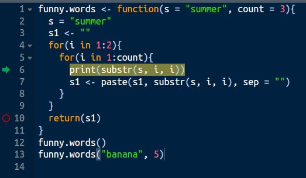

Debugging

Then we can click on “source”" to execute all code until the first breakpoint.

In the console, there will be a new set of buttons:

- If you click on Next, R will execute the next line. (e.g. line 6)
- If you click on the second button, R will step in the current function call, so it will basically jump into an other function. (e.g. into the print function)
- If you click on the third button, R will execute the rest of the current function or loop. (e.g. line 6 and 7)
- If you click on “continue”“, R will run until we come across the next breakpoint. (e.g. in the next round of the loop or in line 10)
- If you click on “Stop”, R will exit the debug mode.

## Exercises

Use the debugging options to find all mistakes in the code above.

# Piping

Some people complain about all the brackets in the R syntax. With using pipes you can get rid of them. Pipes might also reflect your workflow more naturally than the usual syntax.

You can find the standard pipe operator in multiple packages, but you will get more options when using the magrittr packages.

Here is a simple example

```r
library(magrittr)
x <- 9
# Calculate the square-root of x
sqrt(x)
```

```
## [1] 3
```

```r
# Calculate it using pipes
x %>% sqrt
```

```
## [1] 3
```

In case you want to update x, you can use:

```r
x <- 9
# Calculate the square-root of x and update x
x <- sqrt(x)
x
```

```
## [1] 3
```

```r
# Calculate it using pipes
x <- 9
x %<>% sqrt
x
```

```
## [1] 3
```

This is an example with two functions and additional arguments:

```r
nrow(subset(df, hive==4))
```

```
## [1] 60193
```

```r
df %>% subset(hive==4) %>% nrow
```

```
## [1] 60193
```

## Exercises

1. Rewrite following code using pipes:

```r
x <- 2
round(log(x))
```

```
## [1] 1
```

```r
x <- 2
x %<>% log %>% round
```

2. Rewrite the following code using %>% and %<>%:

```r
x <- 2
x <- round(log(x))
x
```

```
## [1] 1
```

2. Rewrite the following code:

```r
x <- rnorm(10,100)
round(sum(sqrt(x)), 3)
```

```
## [1] 100.179
```

```r
x %>% sqrt %>% sum %>% round(3)
```

```
## [1] 100.179
```

# Plotting

## Standard library

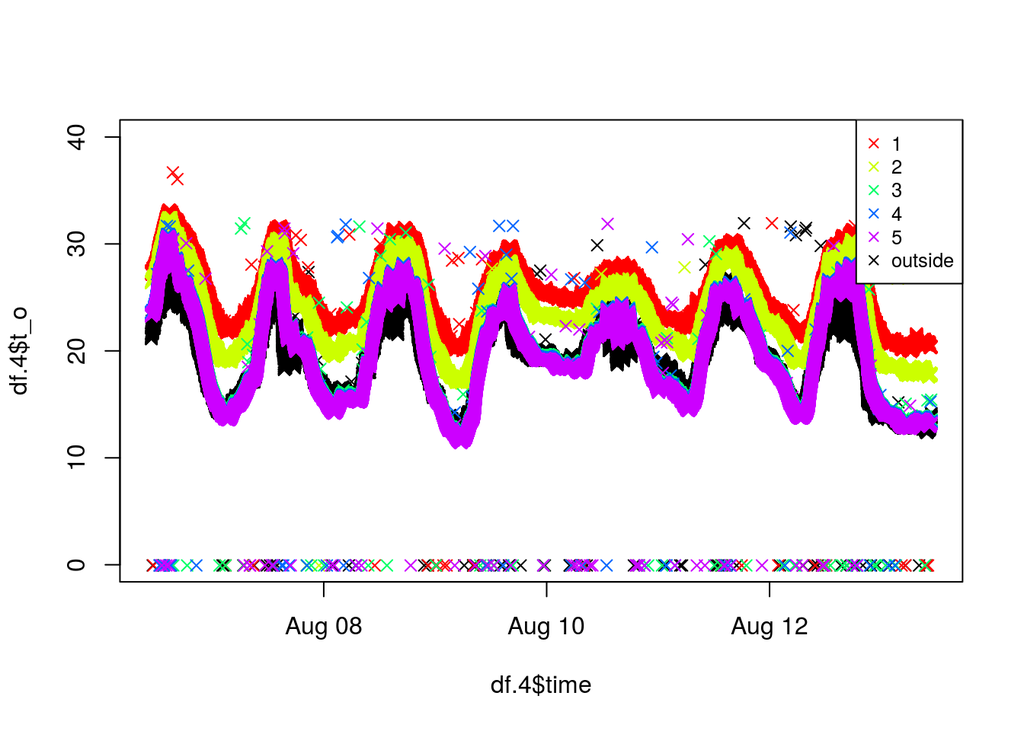

```r
# subset data
df.4 <- df[df$hive==4,]
# plot temperature outside
plot(df.4$time, df.4$t_o, ylim=c(0,40),type = 'p', pch=4)
# choose colours
cl <- rainbow(5)
# choose colums
cols <- 4:8
# plot each column
for (i in 1:5){
    lines(df.4$time, df.4[,cols[i]],col = cl[i],type = 'p', pch=4, ylim=c(0,40))
}
# add legend
legend("topright", legend=c(1, 2, 3, 4, 5, "outside"),
       col=c(cl, "black"), pch = 4, lty = 0, cex=0.8)
```

### Types

- “p”: Points
- “l”: Lines
- “b”: Both

### Line type

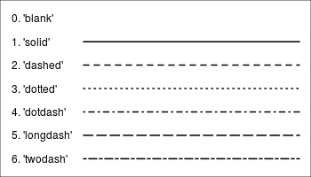

line

## ggplot

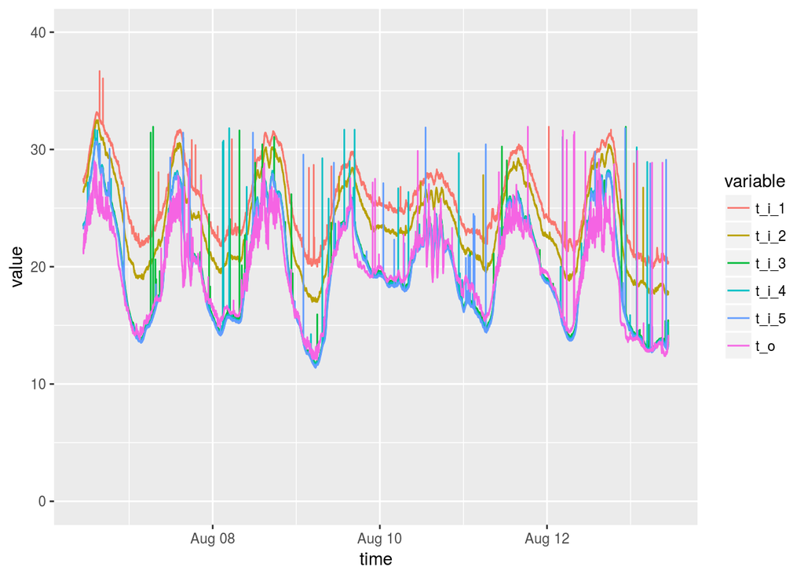

```r
# subset data
df.4 <- df[df$hive==4,]
# choose columns
df.4.cols <- df.4[,c(1,4:9)]
# reshape data
library(reshape)
mdf <- melt(df.4.cols, id=c("time"))
# plot data
library(ggplot2)
ggplot(data = mdf, aes(x=time, y=value)) + geom_line(aes(colour=variable)) + ylim(c(0, 40))
```

# R-Markdown

R-Markdown is a great way to document your code and to write reports about your results.

## Output formats

The three most common output options for R-Markdown are html, pdf and word documents. If you want to create pdf documents, tex needs to be installed.

[figure not shown]

Depending on your choice, your document will have a different output parameter in the header:

```r
# html
---
title: "R Markdown Example"
author: "Somebody"
date: "August 14, 2019"
output: html_document
---
# word
---
title: "R Markdown Example"
author: "Somebody"
date: "August 14, 2019"
output: word_document
---
```

There are many formatting options which you can specify in the header. This might be useful options for html:

```r
---
title: "R Markdown Example"
author: "Somebody"
date: "August 14, 2019"
output:
  html_document:
    toc: true # print a table of content
    toc_depth: 2 # maximal depth of the table of content
    number_sections: true # automatically number the sections
    code_folding: hide # have buttons to show/ hide code
    theme: united # specify a theme
    toc_float: true # generate a navigation bar

---
```

## Document structure

If you create a new R-Markdown document, R will automatically create a sample document. You can see that “#” can be used to create headers:

```r
# Header 1

## Header 2

### Header 3
```

## Code blocks

For code blocks you have many options, too. The two most important are:

- eval: If set to true, the code will be executed
- echo: If set to true, the code will be plotted

## Lists

```r
* unordered list
    + sub-item 1
    + sub-item 2
        - sub-sub-item 1
* item 2

    Continued (indent 4 spaces)

1. ordered list
2. item 2
    i) sub-item 1
```

- unordered list
  - sub-item 1
  - sub-item 2
    - sub-sub-item 1
- item 2

  Continued (indent 4 spaces)
1. ordered list
2. item 2
   1. sub-item 1

## Insert an image

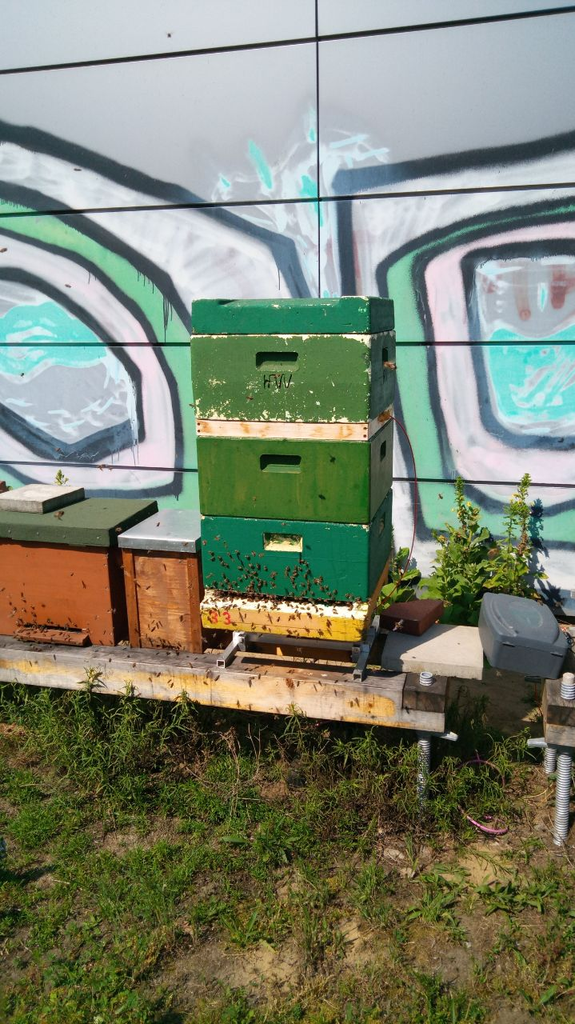

Some description

```r
![Some description](images/photo5197612866222533599.jpg)
```

## Further documentation

A good documentation of R-Markdown can be found here: https://bookdown.org/yihui/rmarkdown/

And here is a cheat sheet: https://www.rstudio.com/resources/cheatsheets/#rmarkdown

## Exercise

1. Create your own R-Markdown document.
2. Go through this chapter and try out the options and functionalities.

# Assignment

- Create an R-Markdown document
- Choose a dataset
- Choose 3 of the following tasks for a small assignment and 8 for a large assignment. You can also come up with own ideas.
- Write a short text for each task explaining what you have been doing
- If you are doing the large assignment, make sure to write about the origin of your data, the motivation for the analysis and discuss your results

### Ideas

- Make some exploratory analysis:
  - print the mean/ median/ standard deviation for each column
  - print the total number of missing values
  - print the number of missing values for each column
- Transform some of the columns/ Create new columns based on existing ones
- Create a subset of your data
- Exclude all rows with missing values
- Create a plot
- Write a function that takes a filename and some additional parameters. The function should create a plot and save it as “png” with that filename
- Create a linear model

# More about the data

## Bees

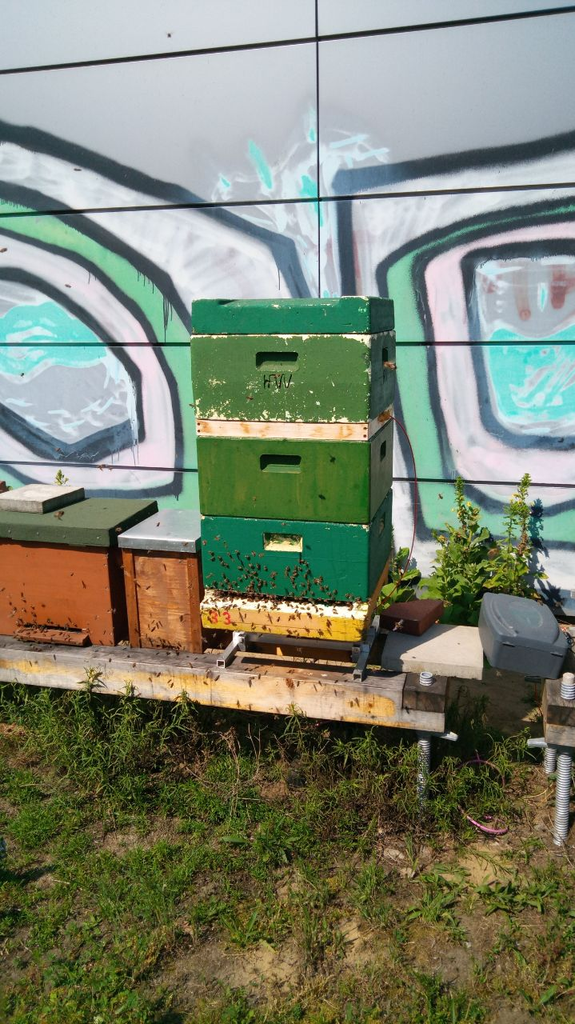

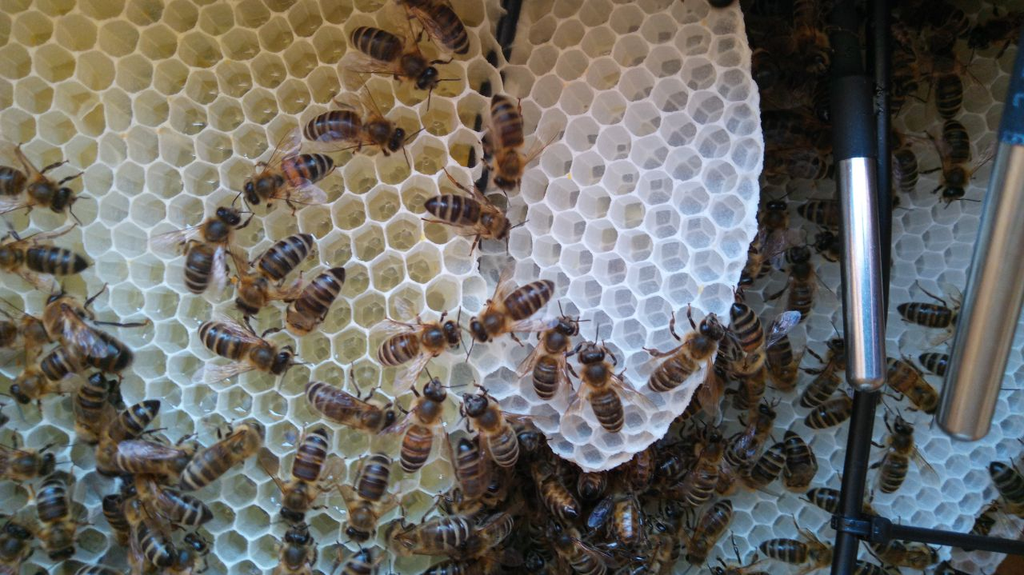

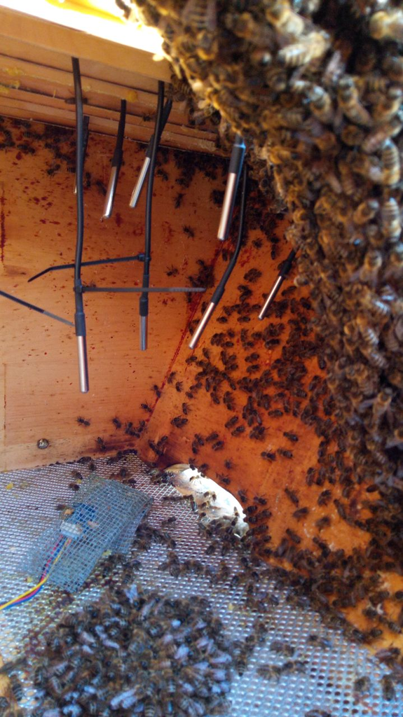

- hive 3: University of Bremen
- hive 4: University of Bremen
- hive 12: Kolja, Bremen
- hive 13: Micha, Hamburg
- hive 14: Ralf, Bielefeld

```r
df <- read.table("beedata.csv", sep = ",", header = T)
```

| time | hive | h | t_i_1 | t_i_2 | t_i_3 | t_i_4 | t_i_5 | t_o | weight_kg |
| --- | --- | --- | --- | --- | --- | --- | --- | --- | --- |
| 1.565081e+18 | 4 | NA | 27.250 | 26.3750 | 23.4375 | 23.5000 | 23.2500 | 21.625 | NA |
| 1.565081e+18 | 4 | NA | 27.250 | 26.4375 | 23.5000 | 23.5000 | 23.2500 | 21.625 | NA |
| 1.565081e+18 | 13 | 59.0554 | 22.875 | 22.1875 | 23.0000 | 21.8125 | 22.6875 | 22.875 | 10.779 |
| 1.565081e+18 | 4 | NA | 27.250 | 26.3750 | 23.5000 | 23.5625 | 23.2500 | 21.625 | NA |
| 1.565081e+18 | 4 | NA | 27.250 | 26.3750 | 23.5000 | 23.5625 | 23.2500 | 21.625 | NA |

- Time: Timestamp in Nanosecond
- h: humidity within the hive
- t_i_x: temperature within the hive
- t_o: outside temperature
- weight_kg: weight including hive

## Forarex

[figure not shown]

http://foralex.de/en/

Student project, sending single-celled organisms to space.

# Short statistical breaks

## Dinosour

https://www.autodeskresearch.com/publications/samestats

## Stars

[figure not shown]

Stars

I don’t know the source, I hope you forgive me.

## Spurious-correlations

https://www.tylervigen.com/spurious-correlations

## Being healthy

https://youtu.be/sTy9e9VMpeo?t=1h8m44s